# Calidad de código y refactorización

Del código que funciona al pipeline en el que un equipo puede confiar

## Cómo trabajaremos hoy

INGENIERÍA BIOMÉDICA · SALUD DIGITAL · IA EMBEBIDA

Andreas Cardona

- Electrónica de adquisición y sistemas embebidos
- IA y *deep learning* en microcontroladores
- Python, C, bibliotecas de IA y *world models*
- Profesor de Circuitos Integrados en la UPC

IRIS · Onalabs · NTT DATA · Banc de Sang i Teixits

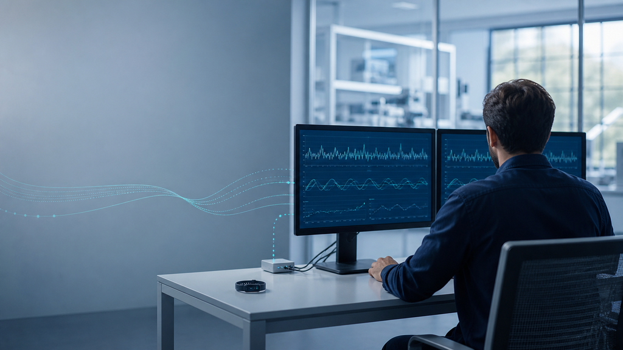

## La calidad hace que el código sea utilizable por un equipo

El código tiene calidad cuando una persona distinta puede **entenderlo, ejecutarlo y confiar en su resultado**.

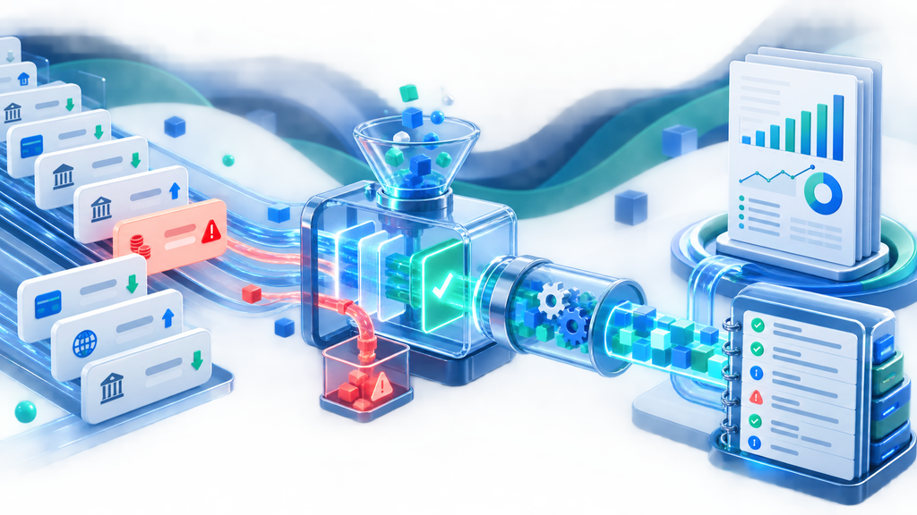

## Qué resolveremos en esta sesión

01**¿Qué debe validarse antes de procesar?**

Contrato de entrada y política de incidencias.

02**¿Cómo localizamos un fallo?**

Excepciones específicas y logs con contexto.

03**¿Cómo comprobamos que el resultado esperado se mantiene?**

Funciones separadas, copias y `assert`.

04**¿Cómo lo trasladamos a un equipo?**

Un pipeline reutilizable y un resumen inspeccionable.

Al terminar podrás convertir código heredado en una primera versión operable.

## La calidad básica es el punto de partida, no el final

REPASO RÁPIDO

La legibilidad reduce el coste de entender y cambiar el código.

**Nombres**`importe_total`, no `x`

**Funciones**`limpiar_operaciones(df)`

**Formato (PEP 8)**Sangría, espacios y líneas fáciles de leer

**Tipos y *docstrings***qué entra, qué sale y por qué

**Sin efectos laterales**`datos = df.copy()`

**Tests**`assert` sobre reglas importantes

**Hoy:** calidad de ejecución — qué ocurre cuando el pipeline recibe datos reales, falla, se reejecuta o cambia de manos.

## Un informe que “no se pudo generar” no ayuda a nadie

MENSAJE HEREDADO

`El informe no se ha podido generar`

PREGUNTA PROFESIONAL

¿Se puede publicar el informe?

Si no, ¿quién debe actuar y con qué evidencia?

Faltan etapa, causa, filas afectadas y una acción siguiente.

## No todas las incidencias se tratan igual

CONTINUAR · INFO**Inicio, fin y métricas**

Contexto de una ejecución correcta.

NORMALIZAR · WARNING**Canal no reconocido**

Convertir a `otro` y dejar evidencia.

EXCLUIR · WARNING**Fecha, cliente o importe inválido**

Excluir, contar y comunicar la pérdida.

DETENER · ERROR**Falta una columna obligatoria**

`ContratoDatosError`: no se puede interpretar el dataset.

La escala une acción y severidad: `INFO` informa; `WARNING` permite continuar dejando evidencia; `ERROR` detiene el proceso porque no hay un resultado fiable.

## `print()` sirve para explorar; logging sirve para operar

DURANTE UNA EXPLORACIÓN

```python
print("filas descartadas:", filas_descartadas)
```

Rápido y útil mientras pensamos.

No tiene nivel, destino persistente ni contexto suficiente si el proceso se ejecuta sin supervisión.

DENTRO DE UN PIPELINE

```python
logger.warning(
    "Filas excluidas | filas=%d", filas_descartadas
)
```

Puede filtrarse, guardarse, buscarse y relacionarse con una etapa concreta.

## Un pipeline profesional separa responsabilidades

01**Validar**

¿Puedo interpretar el dataset?

02**Diagnosticar**

¿Qué incidencias hay?

03**Limpiar**

¿Qué filas conservo?

04**Clasificar**

¿Qué regla aplico?

05**Resumir**

¿Qué resultado entrego?

06**Verificar**

¿Se mantiene el contrato?

## Refactorizar también es proteger el comportamiento

LA REGLA

Una mejora no debe cambiar accidentalmente el informe.

Las copias evitan efectos laterales; los tests convierten reglas de negocio en expectativas verificables.

```python
entrada = operaciones.copy(deep=True)
resultado = clasificar_revision(entrada)

assert_frame_equal(entrada, operaciones)
assert resultado["importe"].ge(0).all()
```

## Logging responde a preguntas que `print()` no puede sostener

INFO**¿Qué etapa se ha completado?**

Inicio, fin, métricas y resultado.

WARNING**¿Qué se corrigió, pero permite continuar?**

Filas excluidas, canales normalizados y calidad degradada.

ERROR**¿Qué impide un resultado fiable?**

Contratos incumplidos y fuentes no disponibles.

El mismo logger puede informar en pantalla durante el desarrollo y dejar auditoría en fichero durante una ejecución nocturna.

## Del criterio al código

La calidad no se añade al final: se diseña en cada etapa del pipeline.

## En el notebook veremos

01**Diagnosticar**

Ejecutamos el código heredado e identificamos qué información falta para resolver la incidencia.

02**Construir**

Recorremos validación, limpieza, clasificación, logging y resumen.

03**Verificar**

El sanity check comprueba que la entrada no cambia y que el resultado es coherente.

Pregunta de control: ¿publicarías este informe con 4 filas excluidas de 400?

## Práctica: recuperar el informe diario

01**Decidir**

Convertir las incidencias de calidad en una decisión de publicación.

02**Priorizar**

Asignar prioridades con reglas vectorizadas sin modificar la entrada.

03**Trazar**

Elegir niveles de log y comprobar el contrato de datos.

04**Proteger**

Extraer reglas reutilizables y comprobar casos límite con `assert`.

Primero desde la celda vacía; después, si hace falta, con la ayuda desplegable.

## Cierre: la robustez se diseña

La robustez no evita todos los datos incorrectos: hace visibles las decisiones y permite explicar el resultado.

01**Contrato claro**

Sabemos qué datos son necesarios antes de procesarlos.

02**Decisiones trazables**

Podemos explicar qué se corrigió, excluyó o detuvo.

03**Resultado verificable**

Protegemos las reglas que no deben cambiar.

Antes de optimizar, desplegar o ampliar: ¿qué valida?, ¿qué registra y qué protege este proceso?

## Muchas Gracias

[figure not shown]

[figure not shown]